# Prediccion de Tipo de Transporte - Proyecto de Transporte

### General: Objetivos del Proyecto y Definición de Variables

El objetivo principal de este proyecto es desarrollar un modelo basado en **Máquinas de Vectores de Soporte (SVM)** para predecir el **modo de transporte** utilizado por un individuo en función de los datos recopilados por sensores de dispositivos móviles. Se busca analizar cómo las diferentes señales captadas por el acelerómetro, giróscopo, barómetro, GPS y magnetómetro pueden ser utilizadas para inferir con precisión el medio de transporte en uso.

Para lograr esto, se cuenta con un conjunto de datos que incluye:

1. **Registro Temporal**
   - Cada observación está asociada a un instante de tiempo específico.
2. **Datos de Movimiento y Orientación**
   - **Acelerómetro**: Componentes X, Y, Z del vector aceleración.
   - **Giróscopo**: Velocidad angular en los ejes X, Y, Z y su derivada.
   - **Matriz de Rotación y Cuaterniones**: Representan la orientación tridimensional del dispositivo.
3. **Datos de Ubicación y Contexto**
   - **GPS**: Coordenadas de latitud y longitud, velocidad, altitud y rumbo.
   - **Presión Atmosférica**: Valores obtenidos del barómetro, junto con la altitud relativa.
   - **Campo Magnético Terrestre**: Medición en los ejes X, Y, Z.
4. **Variables Categóricas**
   - **Modo de Transporte**: La categoría que se busca predecir (caminar, bicicleta, automóvil, etc.).
   - **Nivel de Confianza**: Un indicador de la precisión estimada para la clasificación del transporte en los datos originales.

### Objetivo Notebook:

# **1. Carga de librerías**

```r
# Lista de paquetes necesarios
necessary_packages <- c("dplyr", "caret", "e1071", "robustbase", "ggplot2", "data.table", "pROC","doParallel")

# Instalar paquetes que no están instalados
new_packages <- necessary_packages[!(necessary_packages %in% installed.packages()[, "Package"])]
if (length(new_packages) > 0) {
  install.packages(new_packages)
}

# Cargar todos los paquetes
lapply(necessary_packages, library, character.only = TRUE)
```

[output not shown]

```r
# Cargar las librerías necesarias
library(caret)      # Para división estratificada y evaluación de modelos
library(scales)     # Para Min-Max Scaling
library(e1071)      # Para entrenar SVM
library(randomForest)  # Para obtener la importancia de las variables
library(dplyr)      # Para manipulación de datos
# Cargar la librería
library(visdat)
# Cargar la librería
library(tidyr)
# Cargar el paquete 'car'
library(car)
library(ggplot2)
library(stringr) #Cambiar variables
library(DMwR)  # Para SMOTE
```

# 2. Cargar el dataset

```r
# Ruta del archivo CSV (modificar según tu sistema)
ruta_dataset <- "C:/Users/Lenovo/Documents/IT Academy/Datos proyecto 8/proyect8/data_vars_imputadas.csv"
data <- read.csv(ruta_dataset)


data <- read.csv(ruta_dataset)

# Resumen del dataset
cat("### Información General del Dataset")
```

```
### Información General del Dataset
```

```r
dim(data) # Dimensiones del dataset
```

```
[1] 25491    25
```

```r
str(data) # Estructura del dataset
```

```
'data.frame':   25491 obs. of  25 variables:
 $ accelX.g.               : num  0.0437 0.0405 -0.1734 0.1984 -0.0991 ...
 $ accelY.g.               : num  -0.625 -0.636 -0.308 -0.417 -0.652 ...
 $ accelZ.g.               : num  -0.7299 -0.7556 -0.0805 -1.0315 -0.8322 ...
 $ accelUserX.g.           : num  0.0137 0.0119 -0.1732 -0.0111 -0.1217 ...
 $ accelUserY.g.           : num  0.0009 -0.0026 0.3564 0.1551 -0.2809 ...
 $ accelUserZ.g.           : num  0.058 0.0242 0.6277 -0.2601 0.091 ...
 $ gyroX.rad.s.            : num  0.0985 -0.0539 -0.1249 -1.0331 0.4942 ...
 $ gyroY.rad.s.            : num  0.0902 0.0716 0.0633 1.0555 0.2636 ...
 $ gyroZ.rad.s.            : num  -0.0039 -0.1416 -0.021 -1.2428 -1.5661 ...
 $ Roll.rads.              : num  0.0347 0.0338 -0.009 0.3746 0.0522 ...
 $ Pitch.rads.             : num  0.681 0.68 0.713 0.385 0.384 ...
 $ Yaw.rads.               : num  -0.0248 2.1585 2.1856 1.9195 1.8733 ...
 $ m11                     : num  1 -0.572 -0.572 -0.447 -0.316 ...
 $ m12                     : num  -0.0029 0.82 0.8203 0.8277 0.9475 ...
 $ m13                     : num  -0.0269 -0.0263 0.0068 -0.3391 -0.0483 ...
 $ m21                     : num  0.0192 -0.647 -0.6179 -0.871 -0.8851 ...
 $ m22                     : num  0.776 -0.431 -0.436 -0.317 -0.276 ...
 $ m23                     : num  0.63 0.629 0.654 0.376 0.375 ...
 $ m31                     : num  0.0191 0.5044 0.5396 0.2034 0.3416 ...
 $ m32                     : num  -0.63 0.377 0.37 0.463 0.161 ...
 $ m33                     : num  0.776 0.777 0.756 0.863 0.926 ...
 $ ActivityType            : chr  "Coche_autopista" "Coche_autopista" "Coche_autopista" "Coche_autopista" ...
 $ Pressure.kilopascals.   : num  97.1 97.1 97.1 97.1 97.1 ...
 $ RelativeAltitude.meters.: num  -0.214 -0.214 -0.214 -0.214 -0.214 ...
 $ herzios                 : int  2 2 2 2 2 2 2 2 2 2 ...
```

```r
summary(data) # Resumen estadístico básico
```

```
   accelX.g.          accelY.g.         accelZ.g.       accelUserX.g.       accelUserY.g.       accelUserZ.g.        gyroX.rad.s.       gyroY.rad.s.        gyroZ.rad.s.         Roll.rads.
 Min.   :-0.85820   Min.   :-1.0336   Min.   :-1.6804   Min.   :-0.683400   Min.   :-0.409300   Min.   :-0.763000   Min.   :-2.97000   Min.   :-4.737200   Min.   :-6.740700   Min.   :-0.8404
 1st Qu.:-0.07185   1st Qu.:-0.0105   1st Qu.:-0.9862   1st Qu.:-0.016600   1st Qu.:-0.034550   1st Qu.:-0.019000   1st Qu.:-0.06305   1st Qu.:-0.026650   1st Qu.:-0.020700   1st Qu.:-0.0609
 Median :-0.00180   Median : 0.0707   Median :-0.9602   Median :-0.001300   Median :-0.008600   Median : 0.010700   Median :-0.03020   Median : 0.005000   Median :-0.008200   Median : 0.0089
 Mean   : 0.02337   Mean   : 0.1015   Mean   :-0.7595   Mean   : 0.003747   Mean   :-0.004326   Mean   : 0.007049   Mean   :-0.02769   Mean   : 0.002209   Mean   :-0.006238   Mean   : 0.1529
 3rd Qu.: 0.07310   3rd Qu.: 0.2398   3rd Qu.:-0.7732   3rd Qu.: 0.019800   3rd Qu.: 0.024500   3rd Qu.: 0.032700   3rd Qu.: 0.01320   3rd Qu.: 0.047650   3rd Qu.: 0.006400   3rd Qu.: 0.0634
 Max.   : 2.08900   Max.   : 1.0647   Max.   : 0.9785   Max.   : 1.441200   Max.   : 1.063900   Max.   : 1.262000   Max.   : 5.01590   Max.   : 6.693200   Max.   : 4.885300   Max.   : 2.8364
  Pitch.rads.        Yaw.rads.            m11               m12               m13                m21               m22               m23               m31               m32                m33
 Min.   :-0.9552   Min.   :-3.1416   Min.   :-0.9989   Min.   :-0.9997   Min.   :-0.95190   Min.   :-0.9830   Min.   :-0.9999   Min.   :-0.8164   Min.   :-0.9756   Min.   :-0.74720   Min.   :-0.9465
 1st Qu.:-0.2693   1st Qu.:-2.0061   1st Qu.:-0.7109   1st Qu.:-0.7037   1st Qu.:-0.06320   1st Qu.:-0.3786   1st Qu.:-0.7375   1st Qu.:-0.2661   1st Qu.:-0.4123   1st Qu.:-0.11020   1st Qu.: 0.7563
 Median :-0.0828   Median :-0.4486   Median :-0.2219   Median :-0.4315   Median :-0.00880   Median : 0.4311   Median :-0.4172   Median :-0.0827   Median :-0.0066   Median :-0.02260   Median : 0.9894
 Mean   :-0.1109   Mean   :-0.1836   Mean   :-0.1140   Mean   :-0.1447   Mean   :-0.02089   Mean   : 0.1656   Mean   :-0.2393   Mean   :-0.1072   Mean   :-0.1773   Mean   :-0.02027   Mean   : 0.7658
 3rd Qu.:-0.0156   3rd Qu.: 1.5235   3rd Qu.: 0.4187   3rd Qu.: 0.4598   3rd Qu.: 0.06000   3rd Qu.: 0.7056   3rd Qu.: 0.1726   3rd Qu.:-0.0156   3rd Qu.: 0.0200   3rd Qu.: 0.04640   3rd Qu.: 0.9963
 Max.   : 1.4767   Max.   : 3.1415   Max.   : 1.0000   Max.   : 0.9997   Max.   : 0.72420   Max.   : 0.9997   Max.   : 0.9906   Max.   : 0.9956   Max.   : 0.9765   Max.   : 0.66420   Max.   : 1.0000
 ActivityType       Pressure.kilopascals. RelativeAltitude.meters.    herzios
 Length:25491       Min.   : 96.97        Min.   :-65.9100         Min.   :  2.0
 Class :character   1st Qu.:101.58        1st Qu.: -0.5443         1st Qu.: 50.0
 Mode  :character   Median :102.06        Median :  9.9933         Median :100.0
                    Mean   :101.73        Mean   : 15.7070         Mean   :124.5
                    3rd Qu.:102.53        3rd Qu.: 35.9673         3rd Qu.:250.0
                    Max.   :102.57        Max.   : 38.2872         Max.   :250.0
```

## 2.1 Selección de las Variables de acuerdo a RF, VIF y Anova

```r
# Seleccionar solo las variables relevantes
data_filtrado <- data %>%
  select(accelX.g., accelZ.g., accelY.g.,  # Aceleración
         Roll.rads., Pitch.rads., Yaw.rads., gyroY.rad.s.,  # Giroscopios
         Pressure.kilopascals., herzios,  # Contexto ambiental
         m33,  # Componentes de Movimiento
         ActivityType)  # Variable objetivo

# Guardar el dataset actualizado
write.csv(data_filtrado, "dataset_filtrado.csv", row.names = FALSE)

# Mostrar primeras filas del dataset filtrado
head(data_filtrado)
```

|  | accelX.g. | accelZ.g. | accelY.g. | Roll.rads. | Pitch.rads. | Yaw.rads. | gyroY.rad.s. | Pressure.kilopascals. | herzios | m33 | ActivityType |
| --- | --- | --- | --- | --- | --- | --- | --- | --- | --- | --- | --- |
| 1 | 0.0437 | -0.7299 | -0.6249 | 0.0347 | 0.6813 | -0.0248 | 0.0902 | 97.0946 | 2 | 0.7763 | Coche_autopista |
| 2 | 0.0405 | -0.7556 | -0.6357 | 0.0338 | 0.6803 | 2.1585 | 0.0716 | 97.0946 | 2 | 0.7770 | Coche_autopista |
| 3 | -0.1734 | -0.0805 | -0.3077 | -0.0090 | 0.7131 | 2.1856 | 0.0633 | 97.0946 | 2 | 0.7563 | Coche_autopista |
| 4 | 0.1984 | -1.0315 | -0.4168 | 0.3746 | 0.3850 | 1.9195 | 1.0555 | 97.0946 | 2 | 0.8625 | Coche_autopista |
| 5 | -0.0991 | -0.8322 | -0.6518 | 0.0522 | 0.3840 | 1.8733 | 0.2636 | 97.0946 | 2 | 0.9259 | Coche_autopista |
| 6 | -0.0382 | -0.9711 | -0.2162 | 0.0116 | 0.2579 | 1.8729 | -0.3883 | 97.0948 | 2 | 0.9669 | Coche_autopista |

```r
str( data_filtrado)
```

```
'data.frame':   25491 obs. of  11 variables:
 $ accelX.g.            : num  0.0437 0.0405 -0.1734 0.1984 -0.0991 ...
 $ accelZ.g.            : num  -0.7299 -0.7556 -0.0805 -1.0315 -0.8322 ...
 $ accelY.g.            : num  -0.625 -0.636 -0.308 -0.417 -0.652 ...
 $ Roll.rads.           : num  0.0347 0.0338 -0.009 0.3746 0.0522 ...
 $ Pitch.rads.          : num  0.681 0.68 0.713 0.385 0.384 ...
 $ Yaw.rads.            : num  -0.0248 2.1585 2.1856 1.9195 1.8733 ...
 $ gyroY.rad.s.         : num  0.0902 0.0716 0.0633 1.0555 0.2636 ...
 $ Pressure.kilopascals.: num  97.1 97.1 97.1 97.1 97.1 ...
 $ herzios              : int  2 2 2 2 2 2 2 2 2 2 ...
 $ m33                  : num  0.776 0.777 0.756 0.863 0.926 ...
 $ ActivityType         : chr  "Coche_autopista" "Coche_autopista" "Coche_autopista" "Coche_autopista" ...
```

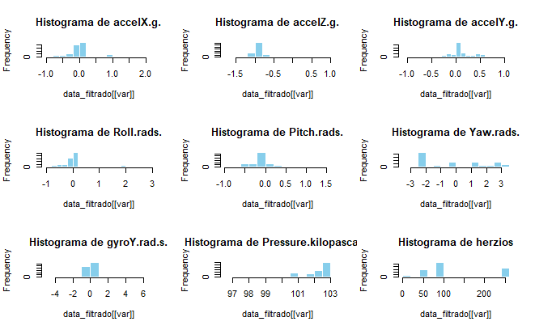

```r
# Variables numéricas en el dataset
numeric_vars <- names(data_filtrado)[sapply(data_filtrado, is.numeric)]

# Graficar histogramas para cada variable numérica
par(mfrow = c(3, 3))  # Organizar en una matriz de 3x3
for (var in numeric_vars) {
  hist(data_filtrado[[var]], main = paste("Histograma de", var), col = "skyblue", border = "white")
}
```

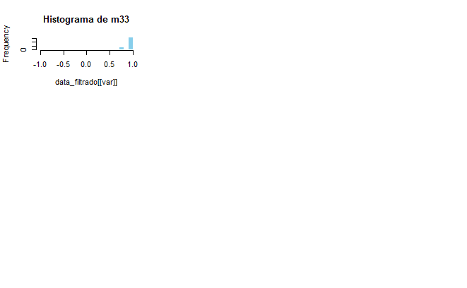

```r
NA
```

# 3. Implementar `class.weights` para ajustar el desbalance de clases.

```r
# Convertir la variable objetivo a factor (si no lo está)
data_filtrado$ActivityType <- as.factor(data_filtrado$ActivityType)

# 1 Convertir Herzios a numérico
data_filtrado <- data_filtrado %>%
  mutate(herzios = as.numeric(herzios))

# Verificar que Herzios ahora es numérico
str(data_filtrado$herzios)
```

```
 num [1:25491] 2 2 2 2 2 2 2 2 2 2 ...
```

```r
summary(data_filtrado$herzios)
```

```
   Min. 1st Qu.  Median    Mean 3rd Qu.    Max.
    2.0    50.0   100.0   124.5   250.0   250.0
```

```r
# Identificar solo las columnas numéricas (excluyendo `ActivityType`)
num_cols <- sapply(data_filtrado, is.numeric)

# Aplicar Min-Max Scaling SOLO a las columnas numéricas
preproc <- preProcess(data_filtrado[, num_cols], method = c("range"))
data_scaled <- predict(preproc, data_filtrado[, num_cols])

# Volver a agregar la variable objetivo `ActivityType`
data_scaled$ActivityType <- data_filtrado$ActivityType

# Verificar la estructura del dataset escalado
str(data_scaled)
```

```
'data.frame':   25491 obs. of  11 variables:
 $ accelX.g.            : num  0.306 0.305 0.232 0.359 0.258 ...
 $ accelZ.g.            : num  0.357 0.348 0.602 0.244 0.319 ...
 $ accelY.g.            : num  0.195 0.19 0.346 0.294 0.182 ...
 $ Roll.rads.           : num  0.238 0.238 0.226 0.33 0.243 ...
 $ Pitch.rads.          : num  0.673 0.673 0.686 0.551 0.551 ...
 $ Yaw.rads.            : num  0.496 0.844 0.848 0.806 0.798 ...
 $ gyroY.rad.s.         : num  0.422 0.421 0.42 0.507 0.438 ...
 $ Pressure.kilopascals.: num  0.0231 0.0231 0.0231 0.0231 0.0231 ...
 $ herzios              : num  0 0 0 0 0 0 0 0 0 0 ...
 $ m33                  : num  0.885 0.885 0.875 0.929 0.962 ...
 $ ActivityType         : Factor w/ 6 levels "Andando","Autobus",..: 5 5 5 5 5 5 5 5 5 5 ...
```

```r
summary(data_scaled)
```

```
   accelX.g.        accelZ.g.        accelY.g.        Roll.rads.      Pitch.rads.       Yaw.rads.       gyroY.rad.s.    Pressure.kilopascals.    herzios            m33                  ActivityType
 Min.   :0.0000   Min.   :0.0000   Min.   :0.0000   Min.   :0.0000   Min.   :0.0000   Min.   :0.0000   Min.   :0.0000   Min.   :0.0000        Min.   :0.0000   Min.   :0.0000   Andando        : 4976
 1st Qu.:0.2668   1st Qu.:0.2611   1st Qu.:0.4876   1st Qu.:0.2120   1st Qu.:0.2820   1st Qu.:0.1807   1st Qu.:0.4121   1st Qu.:0.8239        1st Qu.:0.1935   1st Qu.:0.8748   Autobus        : 2679
 Median :0.2906   Median :0.2709   Median :0.5263   Median :0.2310   Median :0.3587   Median :0.4286   Median :0.4149   Median :0.9088        Median :0.3952   Median :0.9946   Avion          :  816
 Mean   :0.2991   Mean   :0.3463   Mean   :0.5410   Mean   :0.2702   Mean   :0.3472   Mean   :0.4708   Mean   :0.4146   Mean   :0.8496        Mean   :0.4941   Mean   :0.8797   Bicicleta      : 2985
 3rd Qu.:0.3160   3rd Qu.:0.3412   3rd Qu.:0.6069   3rd Qu.:0.2458   3rd Qu.:0.3864   3rd Qu.:0.7425   3rd Qu.:0.4186   3rd Qu.:0.9924        3rd Qu.:1.0000   3rd Qu.:0.9981   Coche_autopista: 1741
 Max.   :1.0000   Max.   :1.0000   Max.   :1.0000   Max.   :1.0000   Max.   :1.0000   Max.   :1.0000   Max.   :1.0000   Max.   :1.0000        Max.   :1.0000   Max.   :1.0000   Coche_urbano   :12294
```

```r
# Verificar si hay NA después del escalado
print("🔎 ¿Hay valores NA después del escalado?")
```

```
[1] "🔎 ¿Hay valores NA después del escalado?"
```

```r
print(any(is.na(data_scaled)))  # Debe ser FALSE
```

```
[1] FALSE
```

```r
# Verificar si las variables están en el rango correcto [0,1]
summary(data_scaled)
```

```
   accelX.g.        accelZ.g.        accelY.g.        Roll.rads.      Pitch.rads.       Yaw.rads.       gyroY.rad.s.    Pressure.kilopascals.    herzios            m33                  ActivityType
 Min.   :0.0000   Min.   :0.0000   Min.   :0.0000   Min.   :0.0000   Min.   :0.0000   Min.   :0.0000   Min.   :0.0000   Min.   :0.0000        Min.   :0.0000   Min.   :0.0000   Andando        : 4976
 1st Qu.:0.2668   1st Qu.:0.2611   1st Qu.:0.4876   1st Qu.:0.2120   1st Qu.:0.2820   1st Qu.:0.1807   1st Qu.:0.4121   1st Qu.:0.8239        1st Qu.:0.1935   1st Qu.:0.8748   Autobus        : 2679
 Median :0.2906   Median :0.2709   Median :0.5263   Median :0.2310   Median :0.3587   Median :0.4286   Median :0.4149   Median :0.9088        Median :0.3952   Median :0.9946   Avion          :  816
 Mean   :0.2991   Mean   :0.3463   Mean   :0.5410   Mean   :0.2702   Mean   :0.3472   Mean   :0.4708   Mean   :0.4146   Mean   :0.8496        Mean   :0.4941   Mean   :0.8797   Bicicleta      : 2985
 3rd Qu.:0.3160   3rd Qu.:0.3412   3rd Qu.:0.6069   3rd Qu.:0.2458   3rd Qu.:0.3864   3rd Qu.:0.7425   3rd Qu.:0.4186   3rd Qu.:0.9924        3rd Qu.:1.0000   3rd Qu.:0.9981   Coche_autopista: 1741
 Max.   :1.0000   Max.   :1.0000   Max.   :1.0000   Max.   :1.0000   Max.   :1.0000   Max.   :1.0000   Max.   :1.0000   Max.   :1.0000        Max.   :1.0000   Max.   :1.0000   Coche_urbano   :12294
```

```r
# 1 Calcular pesos inversamente proporcionales al tamaño de cada clase
class_counts <- table(data_scaled$ActivityType)
class_weights <- 1 / class_counts

# 2 Normalizar dividiendo por el máximo peso
class_weights <- class_weights / max(class_weights)

# 3 Asignar nombres a los pesos
names(class_weights) <- names(class_counts)

# Ver los pesos normalizados
print(class_weights)
```

```
        Andando         Autobus           Avion       Bicicleta Coche_autopista    Coche_urbano
     0.16398714      0.30459127      1.00000000      0.27336683      0.46869615      0.06637384
```

```r
print(class_weights)
```

```
        Andando         Autobus           Avion       Bicicleta Coche_autopista    Coche_urbano
     0.16398714      0.30459127      1.00000000      0.27336683      0.46869615      0.06637384
```

```r
set.seed(123)
trainIndex <- createDataPartition(data_scaled$ActivityType, p = 0.8, list = FALSE)
train_data <- data_scaled[trainIndex, ]
test_data <- data_scaled[-trainIndex, ]
```

```r
print(colnames(train_data))
```

```
 [1] "accelX.g."             "accelZ.g."             "accelY.g."             "Roll.rads."            "Pitch.rads."           "Yaw.rads."             "gyroY.rad.s."          "Pressure.kilopascals."
 [9] "herzios"               "m33"                   "ActivityType"
```

```r
print(colnames(test_data))
```

```
 [1] "accelX.g."             "accelZ.g."             "accelY.g."             "Roll.rads."            "Pitch.rads."           "Yaw.rads."             "gyroY.rad.s."          "Pressure.kilopascals."
 [9] "herzios"               "m33"                   "ActivityType"
```

```r
print(table(train_data$ActivityType))
```

```
        Andando         Autobus           Avion       Bicicleta Coche_autopista    Coche_urbano
           3981            2144             653            2388            1393            9836
```

```r
print(table(test_data$ActivityType))
```

```
        Andando         Autobus           Avion       Bicicleta Coche_autopista    Coche_urbano
            995             535             163             597             348            2458
```

# 4. Entrenar Modelo Kermel Radial:

## 4.1 SVM con Kernel: Radial y pesos inversamente proporcionales al tamaño de cada clase.

```r
# Registrar el tiempo de inicio para el entrenamiento
start_time <- Sys.time()

# Entrenar el modelo SVM con kernel radial y pesos ajustados
svm_model <- svm(ActivityType ~ ., data = train_data, kernel = "radial",
                 cost = 1, gamma = 0.01, class.weights = class_weights)

# Registrar el tiempo de finalización del entrenamiento
end_time <- Sys.time()

# Calcular el tiempo de entrenamiento
training_time <- end_time - start_time
cat("Tiempo de entrenamiento SVM:", training_time, "\n")
```

```
Tiempo de entrenamiento SVM: 9.463126
```

```r
# Registrar el tiempo de inicio para las predicciones
start_time_pred <- Sys.time()

# Hacer predicciones con el modelo corregido
pred_adjusted <- predict(svm_model, test_data)

# Registrar el tiempo de finalización de las predicciones
end_time_pred <- Sys.time()

# Calcular el tiempo de las predicciones
prediction_time <- end_time_pred - start_time_pred
cat("Tiempo para hacer las predicciones:", prediction_time, "\n")
```

```
Tiempo para hacer las predicciones: 0.9185309
```

```r
# Evaluar el modelo con bias ajustado
conf_matrix_adjusted <- confusionMatrix(pred_adjusted, test_data$ActivityType)
print(conf_matrix_adjusted)
```

```
Confusion Matrix and Statistics

                 Reference
Prediction        Andando Autobus Avion Bicicleta Coche_autopista Coche_urbano
  Andando             995       0     0         0               0            0
  Autobus               0     535    15         0               0           61
  Avion                 0       0   148         0               0            0
  Bicicleta             0       0     0       597               0            0
  Coche_autopista       0       0     0         0             348            0
  Coche_urbano          0       0     0         0               0         2397

Overall Statistics

               Accuracy : 0.9851
                 95% CI : (0.9814, 0.9882)
    No Information Rate : 0.4823
    P-Value [Acc > NIR] : < 2.2e-16

                  Kappa : 0.9788

 Mcnemar's Test P-Value : NA

Statistics by Class:

                     Class: Andando Class: Autobus Class: Avion Class: Bicicleta Class: Coche_autopista Class: Coche_urbano
Sensitivity                  1.0000         1.0000      0.90798           1.0000                1.00000              0.9752
Specificity                  1.0000         0.9833      1.00000           1.0000                1.00000              1.0000
Pos Pred Value               1.0000         0.8756      1.00000           1.0000                1.00000              1.0000
Neg Pred Value               1.0000         1.0000      0.99697           1.0000                1.00000              0.9774
Prevalence                   0.1953         0.1050      0.03199           0.1172                0.06829              0.4823
Detection Rate               0.1953         0.1050      0.02904           0.1172                0.06829              0.4704
Detection Prevalence         0.1953         0.1199      0.02904           0.1172                0.06829              0.4704
Balanced Accuracy            1.0000         0.9917      0.95399           1.0000                1.00000              0.9876
```

```r
# Extraer métricas específicas
precision <- conf_matrix$byClass[, "Pos Pred Value"]  # Precisión por clase
recall <- conf_matrix$byClass[, "Sensitivity"]        # Recall por clase
f1_score <- 2 * (precision * recall) / (precision + recall)  # F1-score

# 📌 Mostrar resultados de precisión, recall y F1-score
metrics_results <- data.frame(Class = levels(test_data$ActivityType),
                              Precision = precision,
                              Recall = recall,
                              F1_Score = f1_score)

print(metrics_results)
```

[output not shown]

```r
NA
```

[figure not shown]

```r
library(FactoMineR)
library(factoextra)
library(ggplot2)

# Aplicar PCA para reducir la dimensionalidad (sin incluir la columna ActivityType)
pca_model <- PCA(data_scaled %>% select(-ActivityType), graph = FALSE)

# Extraer los dos primeros componentes principales
pca_data <- as.data.frame(pca_model$ind$coord[, 1:2])  # Solo PC1 y PC2
colnames(pca_data) <- c("PC1", "PC2")

# Agregar las clases reales y predichas
pca_data$Clase_Real <- data_scaled$ActivityType  # Clases reales
pca_data$Predicción <- predict(svm_model_combined, data_scaled)  # Predicciones del modelo

# Graficar PCA con predicciones
ggplot(pca_data, aes(x = PC1, y = PC2, color = Predicción, shape = Clase_Real)) +
  geom_point(alpha = 0.7, size = 2) +
  labs(title = "Separación de Clases con PCA en SVM - Peso Inverso",
       x = "PC1",
       y = "PC2") +
  theme_minimal()
```

## 4.2 SVM con Kernel: Radial y pesos manual.

En vista de los resultados, se realizará una prueba manual de los pesos.

```r
# Aplciar nuevos pesos
class_weights_pesado <- c("Andando" = 10, "Autobus" = 15, "Avion" = 60,
                   "Bicicleta" = 5, "Coche_autopista" = 10, "Coche_urbano" = 1)

# Normalización para que la suma de los pesos sea 1
class_weights_pesadp <- class_weights_pesado / sum(class_weights_pesado)

print(class_weights_pesado)  # Revisar los nuevos pesos normalizados
```

```
        Andando         Autobus           Avion       Bicicleta Coche_autopista    Coche_urbano
             10              15              60               5              10               1
```

```r
# Registrar el tiempo de inicio para el entrenamiento
start_time <- Sys.time()
svm_model <- svm(ActivityType ~ ., data = train_data, kernel = "radial",
                 cost = 0.1, gamma = 0.001, class.weights = class_weights_pesado)
# Registrar el tiempo de finalización del entrenamiento
end_time <- Sys.time()

# Calcular el tiempo de entrenamiento
training_time <- end_time - start_time
cat("Tiempo de entrenamiento SVM:", training_time, "\n")
```

```
Tiempo de entrenamiento SVM: 25.51166
```

```r
pred <- predict(svm_model, test_data)

# Matriz de confusión
conf_matrix <- confusionMatrix(pred, test_data$ActivityType)
print(conf_matrix)
```

```
Confusion Matrix and Statistics

                 Reference
Prediction        Andando Autobus Avion Bicicleta Coche_autopista Coche_urbano
  Andando             995       0     0         0               0            0
  Autobus               0     535    24         0               0           61
  Avion                 0       0   139         0               0            0
  Bicicleta             0       0     0       597               0            0
  Coche_autopista       0       0     0         0             348            0
  Coche_urbano          0       0     0         0               0         2397

Overall Statistics

               Accuracy : 0.9833
                 95% CI : (0.9794, 0.9867)
    No Information Rate : 0.4823
    P-Value [Acc > NIR] : < 2.2e-16

                  Kappa : 0.9763

 Mcnemar's Test P-Value : NA

Statistics by Class:

                     Class: Andando Class: Autobus Class: Avion Class: Bicicleta Class: Coche_autopista Class: Coche_urbano
Sensitivity                  1.0000         1.0000      0.85276           1.0000                1.00000              0.9752
Specificity                  1.0000         0.9814      1.00000           1.0000                1.00000              1.0000
Pos Pred Value               1.0000         0.8629      1.00000           1.0000                1.00000              1.0000
Neg Pred Value               1.0000         1.0000      0.99516           1.0000                1.00000              0.9774
Prevalence                   0.1953         0.1050      0.03199           0.1172                0.06829              0.4823
Detection Rate               0.1953         0.1050      0.02728           0.1172                0.06829              0.4704
Detection Prevalence         0.1953         0.1217      0.02728           0.1172                0.06829              0.4704
Balanced Accuracy            1.0000         0.9907      0.92638           1.0000                1.00000              0.9876
```

```r
# Extraer métricas específicas
precision <- conf_matrix$byClass[, "Pos Pred Value"]  # Precisión por clase
recall <- conf_matrix$byClass[, "Sensitivity"]        # Recall por clase
f1_score <- 2 * (precision * recall) / (precision + recall)  # F1-score

# 📌 Mostrar resultados de precisión, recall y F1-score
metrics_results <- data.frame(Class = levels(test_data$ActivityType),
                              Precision = precision,
                              Recall = recall,
                              F1_Score = f1_score)

print(metrics_results)
```

|  | Class | Precision | Recall | F1_Score |
| --- | --- | --- | --- | --- |
| Class: Andando | Andando | 1.0000000 | 1.0000000 | 1.0000000 |
| Class: Autobus | Autobus | 0.8629032 | 1.0000000 | 0.9264069 |
| Class: Avion | Avion | 1.0000000 | 0.8527607 | 0.9205298 |
| Class: Bicicleta | Bicicleta | 1.0000000 | 1.0000000 | 1.0000000 |
| Class: Coche_autopista | Coche_autopista | 1.0000000 | 1.0000000 | 1.0000000 |
| Class: Coche_urbano | Coche_urbano | 1.0000000 | 0.9751831 | 0.9874356 |

```r
NA
```

[figure not shown]

```r
library(ggplot2)

# Generar predicciones en los datos de prueba
pred <- predict(svm_model_combined, test_data)

# Asegurar que test_data solo tiene variables numéricas antes de PCA
test_data_numeric <- test_data %>%
  select(-ActivityType) %>%
  mutate_if(is.character, as.numeric)  # Convertir caracteres a numéricos si hay errores

# Aplicar PCA a los datos de prueba
pca_result <- prcomp(scale(test_data_numeric))

# Crear un dataframe con los resultados del PCA y las predicciones del modelo
pca_data <- data.frame(
  PC1 = pca_result$x[, 1],
  PC2 = pca_result$x[, 2],
  Predicción = pred,  # Agregamos la predicción del modelo
  Clase_Real = test_data$ActivityType  # Agregamos la clase real
)

# Graficar la separación de clases usando PCA (según la predicción del modelo)
ggplot(pca_data, aes(x = PC1, y = PC2, color = Predicción, shape = Clase_Real)) +
  geom_point(alpha = 0.6, size = 2) +  # 💡 Aquí estaba el error de sintaxis
  labs(title = "Separación de Clases con PCA en SVM - Peso Manual",
       x = "PC1",
       y = "PC2") +
  theme_minimal()
```

## 4.3 SVM con Kernel: Radial y pesos combinados

En lugar de elegir solo una estrategia, podemos:

1. **Promediar** los pesos manuales y los pesos inversos (`class.weights`).
2. **Ajustar los pesos manuales multiplicándolos por un factor basado en la frecuencia inversa de cada clase**.
3. **Escalar los pesos inversos para evitar valores extremos y combinarlos con los manuales**.

```r
# Normalización para que la suma de los pesos sea 1
class_weights_pesado <- class_weights_pesado / sum(class_weights_pesado)

print(class_weights_pesado)  # Revisar los nuevos pesos no
```

```
        Andando         Autobus           Avion       Bicicleta Coche_autopista    Coche_urbano
     0.09900990      0.14851485      0.59405941      0.04950495      0.09900990      0.00990099
```

```r
#Promediamos los pesos calculados automáticamente y los manuales:
class_weights_combined <- (class_weights + class_weights_pesado) / 2
```

```r
#Método de Ajuste por Factor Escalado
scaling_factor <- 0.5 + (class_weights - min(class_weights)) / (max(class_weights) - min(class_weights))
class_weights_combined <- class_weights_pesado * scaling_factor

class_weights_combined <- class_weights_pesado * 0.75 + class_weights * 0.25
```

```r
# Registrar el tiempo de inicio para el entrenamiento
start_time <- Sys.time()
svm_model_combined <- svm(ActivityType ~ ., data = train_data,
                          kernel = "radial", cost = 1, gamma = 0.01,
                          class.weights = class_weights_combined)

# Registrar el tiempo de finalización del entrenamiento
end_time <- Sys.time()

# Calcular el tiempo de entrenamiento
training_time <- end_time - start_time
cat("Tiempo de entrenamiento SVM:", training_time, "\n")
```

```
Tiempo de entrenamiento SVM: 15.69318
```

```r
pred_2 <- predict(svm_model_combined, test_data)

# Matriz de confusión
conf_matrix_2 <- confusionMatrix(pred_2, test_data$ActivityType)
print(conf_matrix_2)
```

```
Confusion Matrix and Statistics

                 Reference
Prediction        Andando Autobus Avion Bicicleta Coche_autopista Coche_urbano
  Andando             995       0     0         0               0            0
  Autobus               0     535    22         0               0           61
  Avion                 0       0   141         0               0            0
  Bicicleta             0       0     0       597               0            0
  Coche_autopista       0       0     0         0             348            0
  Coche_urbano          0       0     0         0               0         2397

Overall Statistics

               Accuracy : 0.9837
                 95% CI : (0.9798, 0.987)
    No Information Rate : 0.4823
    P-Value [Acc > NIR] : < 2.2e-16

                  Kappa : 0.9768

 Mcnemar's Test P-Value : NA

Statistics by Class:

                     Class: Andando Class: Autobus Class: Avion Class: Bicicleta Class: Coche_autopista Class: Coche_urbano
Sensitivity                  1.0000         1.0000      0.86503           1.0000                1.00000              0.9752
Specificity                  1.0000         0.9818      1.00000           1.0000                1.00000              1.0000
Pos Pred Value               1.0000         0.8657      1.00000           1.0000                1.00000              1.0000
Neg Pred Value               1.0000         1.0000      0.99556           1.0000                1.00000              0.9774
Prevalence                   0.1953         0.1050      0.03199           0.1172                0.06829              0.4823
Detection Rate               0.1953         0.1050      0.02767           0.1172                0.06829              0.4704
Detection Prevalence         0.1953         0.1213      0.02767           0.1172                0.06829              0.4704
Balanced Accuracy            1.0000         0.9909      0.93252           1.0000                1.00000              0.9876
```

```r
# Extraer métricas específicas
precision <- conf_matrix_2$byClass[, "Pos Pred Value"]  # Precisión por clase
recall <- conf_matrix_2$byClass[, "Sensitivity"]        # Recall por clase
f1_score <- 2 * (precision * recall) / (precision + recall)  # F1-score

# 📌 Mostrar resultados de precisión, recall y F1-score
metrics_results_2 <- data.frame(Class = levels(test_data$ActivityType),
                              Precision = precision,
                              Recall = recall,
                              F1_Score = f1_score)

print(metrics_results_2)
```

|  | Class | Precision | Recall | F1_Score |
| --- | --- | --- | --- | --- |
| Class: Andando | Andando | 1.0000000 | 1.0000000 | 1.0000000 |
| Class: Autobus | Autobus | 0.8656958 | 1.0000000 | 0.9280139 |
| Class: Avion | Avion | 1.0000000 | 0.8650307 | 0.9276316 |
| Class: Bicicleta | Bicicleta | 1.0000000 | 1.0000000 | 1.0000000 |
| Class: Coche_autopista | Coche_autopista | 1.0000000 | 1.0000000 | 1.0000000 |
| Class: Coche_urbano | Coche_urbano | 1.0000000 | 0.9751831 | 0.9874356 |

```r
# Generar predicciones en los datos de prueba
predictions <- predict(svm_model_combined, test_data)
```

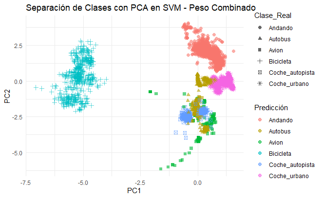

```r
library(ggplot2)
library(ggfortify)

# Generar predicciones en los datos de prueba
pred <- predict(svm_model_combined, test_data)

# Asegurar que test_data solo tiene variables numéricas antes de PCA
test_data_numeric <- test_data %>%
  select(-ActivityType) %>%
  mutate_if(is.character, as.numeric)  # Convertir caracteres a numéricos si es necesario

# Aplicar PCA a los datos de prueba
pca_result <- prcomp(test_data_numeric, scale. = TRUE)

# Crear un dataframe con los resultados del PCA y las predicciones del modelo
pca_data <- data.frame(
  PC1 = pca_result$x[, 1],
  PC2 = pca_result$x[, 2],
  Predicción = pred,  # Agregamos la predicción del modelo
  Clase_Real = test_data$ActivityType  # Agregamos la clase real
)

# Graficar PCA con predicciones del modelo combinado
ggplot(pca_data, aes(x = PC1, y = PC2, color = Predicción, shape = Clase_Real)) +
  geom_point(alpha = 0.6, size = 2) +
  labs(title = "Separación de Clases con PCA en SVM - Peso Combinado",
       x = "PC1",
       y = "PC2") +
  theme_minimal()
```

Se evaluaron tres estrategias de ajuste de pesos en el modelo SVM para la clasificación de tipos de transporte: pesos manuales, pesos inversos y una combinación de ambos. Los resultados muestran que todos los enfoques lograron una alta precisión global (por encima del 98%), pero con diferencias clave en la capacidad de clasificación de clases minoritarias como Autobús y Avión.

### **Conclusión**

Para mejorar esta clasificación, se recomienda **ajustar nuevamente los pesos manuales**, aumentando la penalización por errores en `Autobús` y `Avión`, y realizar **una nueva búsqueda de hiperparámetros (`cost`, `gamma`)** en el modelo SVM para optimizar su capacidad de separación

### 4.3 Busqueda del mejor modelo

La **búsqueda de hiperparámetros** es un proceso esencial en el desarrollo de modelos de Machine Learning, cuyo objetivo es encontrar la combinación más adecuada de parámetros que maximice el rendimiento del modelo. En el caso de un **Support Vector Machine (SVM)** con kernel radial, los parámetros más relevantes son:

- **`C`**: Es el parámetro de penalización que controla la compensación entre margen y los errores de clasificación. Un valor bajo permite más errores en la clasificación, mientras que un valor alto obliga al modelo a ajustarse más estrictamente a los datos, lo que puede resultar en sobreajuste.
- **`sigma` (conocido como `gamma`)**: Este parámetro regula la forma del kernel radial, afectando cómo se miden las distancias entre las muestras. Un valor pequeño de `sigma` hace que el modelo sea más suave y generalice mejor, mientras que un valor grande puede resultar en un modelo que se ajusta demasiado a los datos de entrenamiento, reduciendo su capacidad de generalización.

### **Pasos para la Búsqueda de Hiperparámetros:**

1. **Definición de la Malla de Hiperparámetros:** El primer paso en la búsqueda de los mejores parámetros es definir una **malla de hiperparámetros**. Esta malla consiste en un conjunto de valores posibles para `C` y `sigma` que el modelo probará durante el proceso de entrenamiento. La malla se elige en función de los valores que se consideran más relevantes o que se sabe que pueden ofrecer buenos resultados según el tipo de problema y los datos.
2. **Estrategia de Validación Cruzada:** Para evaluar la eficacia de cada combinación de hiperparámetros, se utiliza **validación cruzada**. Este método divide el conjunto de datos en varios subconjuntos o “pliegues”. El modelo se entrena en algunos de estos subconjuntos y se evalúa en los otros. Esto se repite varias veces para asegurar que el modelo se evalúe de manera robusta y no se sobreajuste a un único conjunto de datos. La validación cruzada ayuda a obtener una estimación más confiable del rendimiento del modelo.

   En este caso, se utilizó una **validación cruzada de 10 pliegues**, lo que significa que el conjunto de datos se divide en 10 partes, y el modelo se entrena y evalúa 10 veces, asegurando que todas las muestras se utilicen tanto para entrenar como para evaluar el modelo.
3. **Entrenamiento con Búsqueda de Hiperparámetros:** Durante el proceso de entrenamiento, el modelo se ajusta repetidamente utilizando cada combinación de valores de `C` y `sigma` definida en la malla de hiperparámetros. Cada combinación se evalúa a través de la validación cruzada, y el rendimiento del modelo se calcula para determinar cuál de las combinaciones proporciona el mejor resultado en términos de precisión, recall, o cualquier otra métrica relevante.
4. **Paralelización del Proceso:** Dado que el proceso de búsqueda de hiperparámetros puede ser computacionalmente costoso, especialmente cuando se utiliza validación cruzada con múltiples combinaciones de parámetros, **paralelización** es una técnica clave para acelerar el proceso. Mediante la paralelización, se distribuyen las cargas de trabajo entre múltiples núcleos del procesador, lo que permite que las pruebas de diferentes combinaciones de hiperparámetros se realicen simultáneamente, reduciendo significativamente el tiempo total de ejecución.
5. **Selección de la Mejor Combinación de Hiperparámetros:** Una vez que se completa la búsqueda, se selecciona el conjunto de hiperparámetros que ha mostrado el mejor rendimiento en términos de la métrica de evaluación. El modelo final es entrenado utilizando esta combinación óptima de parámetros y se utiliza para hacer predicciones sobre nuevos datos.
6. **Liberación de Recursos del Sistema:** Después de completar el proceso de entrenamiento y selección del modelo, es importante liberar los recursos del sistema que se utilizaron para la paralelización. Esto implica cerrar el clúster de núcleos y volver al modo secuencial para evitar sobrecargar el sistema.

```r
library(caret)
library(e1071)
library(doParallel)  # Para paralelización

# 1  Configurar los núcleos para paralelización
num_cores <- detectCores() - 2  # Dejar 2 núcleos libres para evitar bloqueos
cl <- makeCluster(num_cores)  # Crear clúster
registerDoParallel(cl)  # Activar paralelización

# 1 Definir la malla de hiperparámetros correctamente
tune_grid <- expand.grid(
  sigma = c(0.0001, 0.001, 0.01, 0.1, 1),  # Cambiar 'gamma' por 'sigma'
  C = c(0.01, 0.1, 1, 10)
)

# 2  Configurar validación cruzada con paralelización
train_control <- trainControl(method = "cv", number = 10, allowParallel = TRUE)

# 3 Registrar el tiempo de inicio
start_time <- Sys.time()

# 4 Entrenar el modelo SVM con Grid Search paralelizado
svm_tune <- train(ActivityType ~ ., data = train_data,
                   method = "svmRadial",
                   trControl = train_control,
                   tuneGrid = tune_grid,
                   class.weights = class_weights_combined)

# 5 Registrar el tiempo de fin
end_time <- Sys.time()

# Calcular el tiempo total de entrenamiento
training_time <- end_time - start_time
cat("Tiempo total de entrenamiento SVM con Grid Search:", training_time, "\n")
```

```
Tiempo total de entrenamiento SVM con Grid Search: 34.11254
```

```r
# 6 Apagar el clúster después del entrenamiento
stopCluster(cl)
registerDoSEQ()  # Volver al modo secuencial normal
```

```r
# 6 Imprimir los mejores hiperparámetros
print(svm_tune$bestTune)
```

|  | sigma | C |
| --- | --- | --- |
| 16 | 0.1 | 10 |

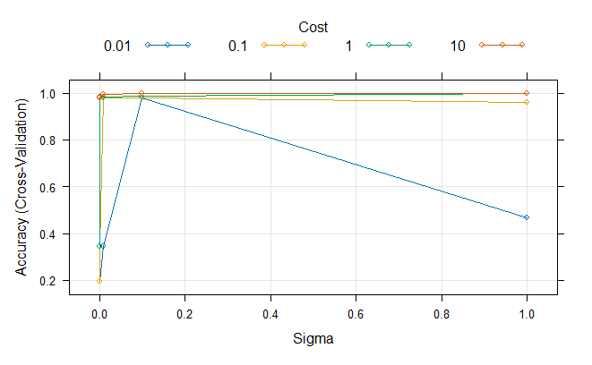

```r
# 7 Visualizar resultados de Grid Search
plot(svm_tune)
```

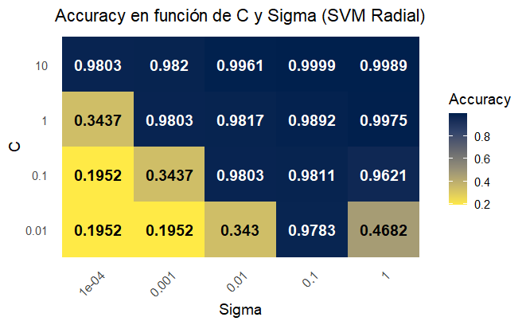

```r
library(viridis)

# 9 **Heatmap de Accuracy en función de C y Sigma para SVM Radial**
# Ordenar resultados por accuracy
tune_results_radial <- svm_tune$results %>%
  select(C, sigma, Accuracy) %>%
  arrange(desc(Accuracy))

# Crear Heatmap con colores equilibrados y etiquetas adaptadas al fondo
ggplot(tune_results_radial, aes(x = factor(sigma), y = factor(C), fill = Accuracy)) +
  geom_tile() +
  scale_fill_viridis_c(option = "cividis", direction = -1, name = "Accuracy") +
  geom_text(aes(label = round(Accuracy, 4),
                color = ifelse(Accuracy > 0.7, "black", "white")),
            size = 5, fontface = "bold") +  # Tamaño más grande para mayor visibilidad
  scale_color_manual(values = c("white", "black"), guide = "none") +
  labs(title = "Accuracy en función de C y Sigma (SVM Radial)",
       x = "Sigma",
       y = "C") +
  theme_minimal(base_size = 14) +
  theme(panel.grid.major = element_blank(),
        panel.grid.minor = element_blank(),
        axis.text.x = element_text(angle = 45, hjust = 1))
```

```r
# Capturar el tiempo de inicio del entrenamiento
start_train_time <- Sys.time()

# Extraer los mejores hiperparámetros encontrados en Grid Search
best_C <- svm_tune$bestTune$C
best_gamma <- svm_tune$bestTune$sigma

# Entrenar el modelo final con los mejores hiperparámetros
svm_final <- svm(ActivityType ~ ., data = train_data, kernel = "radial",
                 cost = 1, gamma = 0.1, class.weights = class_weights_combined)

# Capturar el tiempo de finalización del entrenamiento
end_train_time <- Sys.time()
train_duration <- end_train_time - start_train_time

# Capturar el tiempo de inicio de la predicción
start_pred_time <- Sys.time()

# Hacer predicciones en el conjunto de prueba
pred_final <- predict(svm_final, test_data)

# Capturar el tiempo de finalización de la predicción
end_pred_time <- Sys.time()
pred_duration <- end_pred_time - start_pred_time

# Imprimir los tiempos de ejecución
print(paste("Tiempo de entrenamiento:", train_duration))
```

```
[1] "Tiempo de entrenamiento: 3.60145878791809"
```

```r
print(paste("Tiempo de predicción:", pred_duration))
```

```
[1] "Tiempo de predicción: 0.321635007858276"
```

```r
# Evaluar modelo con Matriz de Confusión
conf_matrix <- confusionMatrix(pred_final, test_data$ActivityType)

# Mostrar matriz de confusión
print(conf_matrix)
```

```
Confusion Matrix and Statistics

                 Reference
Prediction        Andando Autobus Avion Bicicleta Coche_autopista Coche_urbano
  Andando             995       0     0         0               0            0
  Autobus               0     535     0         0               0           10
  Avion                 0       0   163         0               0            0
  Bicicleta             0       0     0       597               0            0
  Coche_autopista       0       0     0         0             348            0
  Coche_urbano          0       0     0         0               0         2448

Overall Statistics

               Accuracy : 0.998
                 95% CI : (0.9964, 0.9991)
    No Information Rate : 0.4823
    P-Value [Acc > NIR] : < 2.2e-16

                  Kappa : 0.9972

 Mcnemar's Test P-Value : NA

Statistics by Class:

                     Class: Andando Class: Autobus Class: Avion Class: Bicicleta Class: Coche_autopista Class: Coche_urbano
Sensitivity                  1.0000         1.0000      1.00000           1.0000                1.00000              0.9959
Specificity                  1.0000         0.9978      1.00000           1.0000                1.00000              1.0000
Pos Pred Value               1.0000         0.9817      1.00000           1.0000                1.00000              1.0000
Neg Pred Value               1.0000         1.0000      1.00000           1.0000                1.00000              0.9962
Prevalence                   0.1953         0.1050      0.03199           0.1172                0.06829              0.4823
Detection Rate               0.1953         0.1050      0.03199           0.1172                0.06829              0.4804
Detection Prevalence         0.1953         0.1069      0.03199           0.1172                0.06829              0.4804
Balanced Accuracy            1.0000         0.9989      1.00000           1.0000                1.00000              0.9980
```

```r
# Extraer métricas específicas
precision <- conf_matrix$byClass[, "Pos Pred Value"]  # Precisión por clase
recall <- conf_matrix$byClass[, "Sensitivity"]        # Recall por clase
f1_score <- 2 * (precision * recall) / (precision + recall)  # F1-score

# Mostrar resultados
print(data.frame(Class = levels(test_data$ActivityType),
                 Precision = precision,
                 Recall = recall,
                 F1_Score = f1_score))
```

|  | Class | Precision | Recall | F1_Score |
| --- | --- | --- | --- | --- |
| Class: Andando | Andando | 1.0000000 | 1.0000000 | 1.0000000 |
| Class: Autobus | Autobus | 0.9816514 | 1.0000000 | 0.9907407 |
| Class: Avion | Avion | 1.0000000 | 1.0000000 | 1.0000000 |
| Class: Bicicleta | Bicicleta | 1.0000000 | 1.0000000 | 1.0000000 |
| Class: Coche_autopista | Coche_autopista | 1.0000000 | 1.0000000 | 1.0000000 |
| Class: Coche_urbano | Coche_urbano | 1.0000000 | 0.9959317 | 0.9979617 |

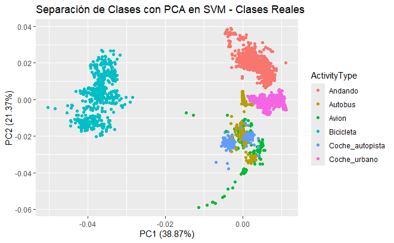

```r
library(ggplot2)
library(ggfortify)

# Generar predicciones en los datos de prueba
pred <- predict(svm_model_combined, test_data)

# Asegurar que test_data solo tiene variables numéricas antes de PCA
test_data_numeric <- test_data %>%
  select(-ActivityType) %>%
  mutate_if(is.character, as.numeric)  # Convertir caracteres a numéricos si es necesario

# Aplicar PCA a los datos de prueba
pca_result <- prcomp(test_data_numeric, scale. = TRUE)

# Crear un dataframe con los resultados del PCA y las predicciones del modelo
pca_data <- data.frame(
  PC1 = pca_result$x[, 1],
  PC2 = pca_result$x[, 2],
  Predicción = pred_final,  # Agregamos la predicción del modelo
  Clase_Real = test_data$ActivityType  # Agregamos la clase real
)

# Graficar PCA con clases reales
autoplot(pca_result, data = test_data, colour = "ActivityType") +
  labs(title = "Separación de Clases con PCA en SVM - Clases Reales")
```

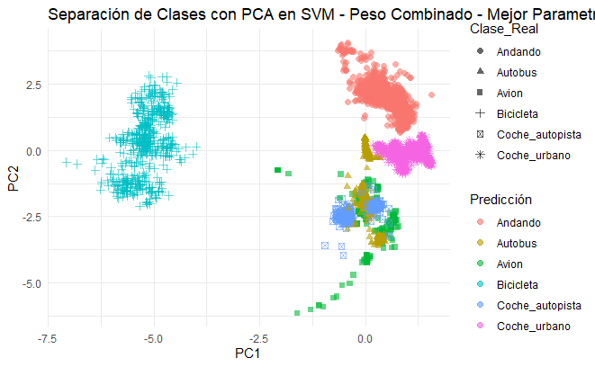

```r
# Graficar PCA con predicciones del modelo combinado
ggplot(pca_data, aes(x = PC1, y = PC2, color = Predicción, shape = Clase_Real)) +
  geom_point(alpha = 0.6, size = 2) +
  labs(title = "Separación de Clases con PCA en SVM - Peso Combinado - Mejor Parametro",
       x = "PC1",
       y = "PC2") +
  theme_minimal()
```

# 5. Resultados:

El desempeño del modelo alcanzó una **precisión global del 99.8%**, con un **Kappa de 0.9972**, indicando una excelente concordancia entre predicciones y valores reales. En términos de sensibilidad y especificidad, la mayoría de las clases obtuvieron valores cercanos a 1.0, asegurando una correcta clasificación de los datos. No obstante, se observó un leve error en la clase “Coche urbano”, con una sensibilidad de **0.9959**, indicando que algunas muestras fueron clasificadas incorrectamente.

Los valores de **Precision, Recall y F1-Score** reflejan el alto rendimiento del modelo. Por ejemplo, “Andando”, “Bicicleta” y “Coche autopista” alcanzaron un **F1-Score de 1.0**, evidenciando una clasificación perfecta. En contraste, “Autobús” mostró un ligero descenso en precisión (**0.9816**), aunque su Recall fue **1.0**, lo que indica que todas las instancias reales de esta clase fueron correctamente detectadas. Este desempeño sugiere que el modelo optimizado logra una separación efectiva entre las clases, con un margen mínimo de error. Sin embargo, considerando que los resultados son casi perfectos, podría existir **riesgo de sobreajuste (overfitting)**, por lo que se recomienda validar el modelo en un conjunto de datos externo para garantizar su generalización.

## Tabla Resumen de SVM - Kernel Radial:

[figure not shown]